# Assignment 7 - Extra Credits: Practice dplyr and ggplot2

*How to do it?*:

- Open the Rmarkdown file of this assignment (link) in Rstudio.
- Right under each **question**, insert a code chunk (you can use the hotkey `Ctrl + Alt + I` to add a code chunk) and code the solution for the question.
- `Knit` the rmarkdown file (hotkey: `Ctrl + Alt + K`) to export an html.
- Publish the html file to your Githiub Page.

*Submission*: Submit the link on Github of the assignment to Canvas

1. Import the data at https://bryantstats.github.io/math421/data/ds_salaries.csv

   The data description can be found at https://www.kaggle.com/datasets/saurabhshahane/data-science-jobs-salaries

```r
library(tidyverse)
df = read_csv("https://bryantstats.github.io/math421/data/ds_salaries.csv")
library(ggplot2)
library(dplyr)
```

2. Is there any column that contains NAs?

```r
colSums(is.na(df))
```

```
##          work_year   experience_level    employment_type          job_title
##                  0                  0                  0                  0
##             salary    salary_currency      salary_in_usd employee_residence
##                  0                  0                  0                  0
##       remote_ratio   company_location       company_size
##                  0                  0                  0
```

No columns contain NA

3. What are the most frequent job titles in the data?

```r
table(df$job_title)
```

```
##
##            3D Computer Vision Researcher
##                                        1
##                             AI Scientist
##                                        7
##                       Analytics Engineer
##                                        4
##                   Applied Data Scientist
##                                        5
##       Applied Machine Learning Scientist
##                                        4
##                          BI Data Analyst
##                                        6
##                       Big Data Architect
##                                        1
##                        Big Data Engineer
##                                        8
##                    Business Data Analyst
##                                        5
##                      Cloud Data Engineer
##                                        2
##                 Computer Vision Engineer
##                                        6
##        Computer Vision Software Engineer
##                                        3
##                             Data Analyst
##                                       97
##                  Data Analytics Engineer
##                                        4
##                      Data Analytics Lead
##                                        1
##                   Data Analytics Manager
##                                        7
##                           Data Architect
##                                       11
##                            Data Engineer
##                                      132
##                 Data Engineering Manager
##                                        5
##                  Data Science Consultant
```

[output cut: 46 more lines]

```
##                                        6
##                             NLP Engineer
##                                        1
##                   Principal Data Analyst
##                                        2
##                  Principal Data Engineer
##                                        3
##                 Principal Data Scientist
##                                        7
##                     Product Data Analyst
##                                        2
##                       Research Scientist
##                                       16
##                     Staff Data Scientist
##                                        1
```

The most frequent jobs are Data Scientist, Data Engineer, and Data Analyst, respectively

4. Find the average salary data of the three most frequent job titles in the data.

```r
df %>% filter(job_title=="Data Scientist"|job_title=="Data Engineer"|job_title=="Data Analyst") %>% group_by(job_title) %>% summarise(average_salary = mean(salary_in_usd))
```

```
## # A tibble: 3 × 2
##   job_title      average_salary
##   <chr>                   <dbl>
## 1 Data Analyst           92893.
## 2 Data Engineer         112725
## 3 Data Scientist        108188.
```

5. What is the job title that has the highest average salary?

```r
df %>% group_by(job_title) %>% summarise(average_salary = mean(salary_in_usd)) %>%
  arrange(-average_salary)
```

```
## # A tibble: 50 × 2
##    job_title                average_salary
##    <chr>                             <dbl>
##  1 Data Analytics Lead             405000
##  2 Principal Data Engineer         328333.
##  3 Financial Data Analyst          275000
##  4 Principal Data Scientist        215242.
##  5 Director of Data Science        195074
##  6 Data Architect                  177874.
##  7 Applied Data Scientist          175655
##  8 Analytics Engineer              175000
##  9 Data Specialist                 165000
## 10 Head of Data                    160163.
## # … with 40 more rows
```

Data Analytics Lead

6. Which country gives the highest salary on average?

```r
df %>% group_by(employee_residence) %>% summarise(average_salary = mean(salary_in_usd)) %>%
  arrange(-average_salary)
```

```
## # A tibble: 57 × 2
##    employee_residence average_salary
##    <chr>                       <dbl>
##  1 MY                        200000
##  2 PR                        160000
##  3 US                        149194.
##  4 NZ                        125000
##  5 CH                        122346
##  6 AU                        108043.
##  7 RU                        105750
##  8 SG                        104176.
##  9 JP                        103538.
## 10 AE                        100000
## # … with 47 more rows
```

Malaysia

7. Plot five meaningful plots. All plots should have title, caption, and appropriate labels.

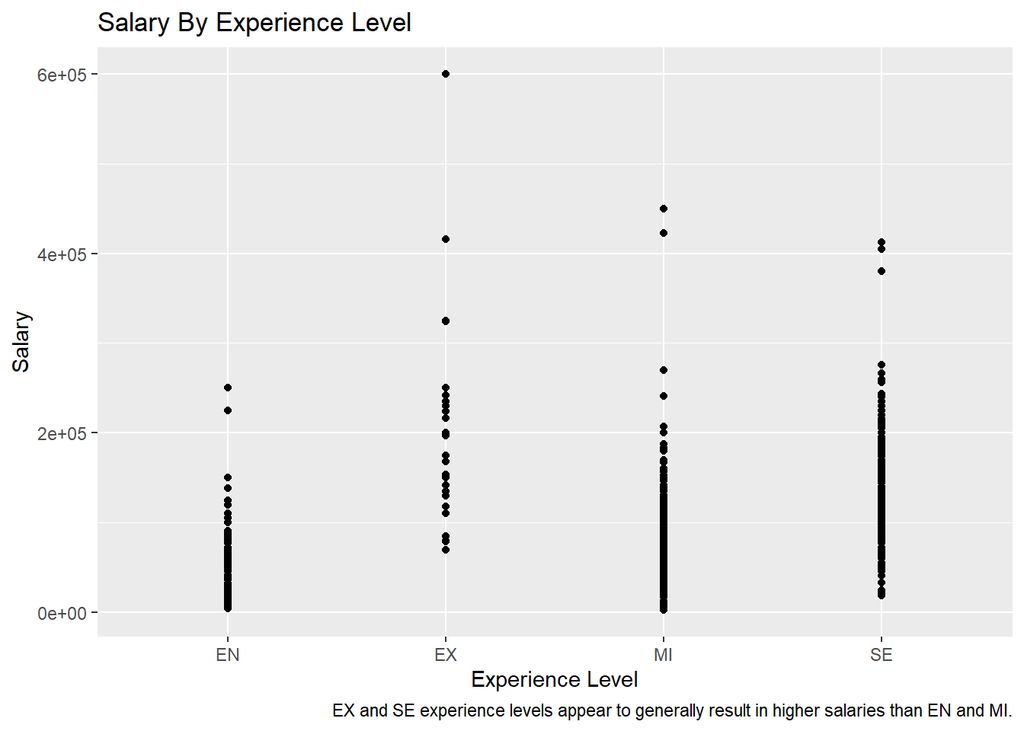

```r
df %>% ggplot() + geom_point(mapping=aes(x=experience_level, y=salary_in_usd)) +
  labs(x='Experience Level',
       y = 'Salary',
       title = 'Salary By Experience Level',
       caption = 'EX and SE experience levels appear to generally result in higher salaries than EN and MI.')
```

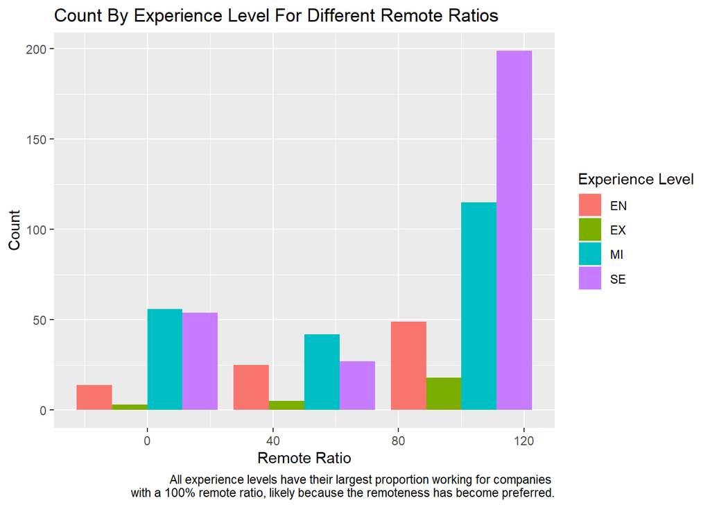

```r
df %>% ggplot() + geom_bar(mapping=aes(x=remote_ratio, fill=experience_level), position = 'dodge') +
    labs(x='Remote Ratio',
         y='Count',
         fill = 'Experience Level',
         title = 'Count By Experience Level For Different Remote Ratios',
         caption = 'All experience levels have their largest proportion working for companies
         with a 100% remote ratio, likely because the remoteness has become preferred.')
```

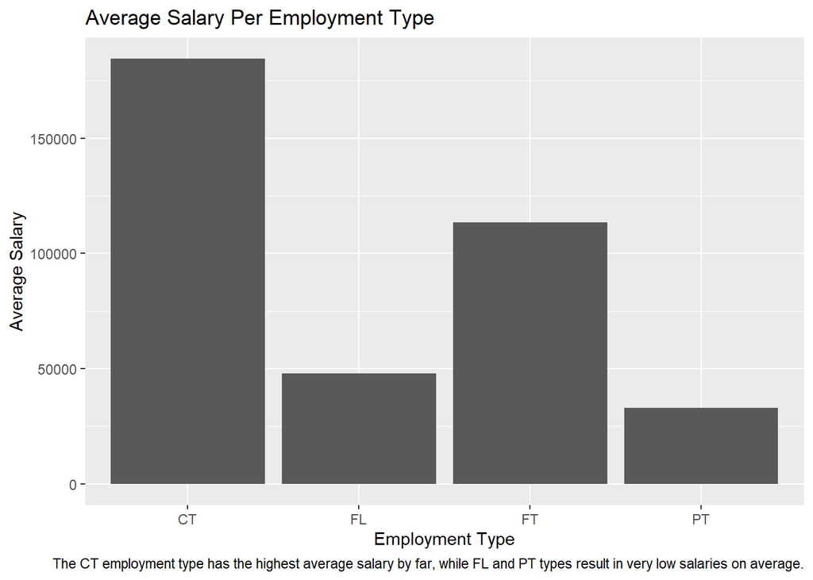

```r
df %>% group_by(employment_type) %>% summarise(average_salary=mean(salary_in_usd)) %>%
  ggplot() + geom_col(mapping=aes(x=employment_type, y=average_salary)) +
  labs(x='Employment Type',
       y='Average Salary',
       title = 'Average Salary Per Employment Type',
       caption = 'The CT employment type has the highest average salary by far, while FL and PT types result in very low salaries on average.')
```

[figure not shown]

```r
df %>% ggplot() + geom_point(mapping=aes(x=work_year, y=salary_in_usd)) +
  facet_wrap(~remote_ratio) +
  labs(x='Year',
       y = 'Salary',
       title = 'Salary by Year and Remote Ratio',
       caption = 'Generally, jobs with 100 remote ratios pay higher salaries, and salaries increased in 2021 and mostly decreased in 2022.')
```

[figure not shown]

```r
df %>% ggplot() + geom_bar(mapping=aes(x=employment_type, fill=experience_level), position = 'dodge') +
    labs(x='Employment Type',
         y='Count',
         fill = 'Experience Level',
         title = 'Count By Experience Level For Different Employment Types',
         caption = 'The majority of data is for FT employees,
         with most of them having SE or MI experience levels,
         while the other employment types do not even contain all 4 experience levels.')
```